# Exam 1

## Exam 1

#### Metainformation

1. | Tag | Value |
   | --- | --- |
   | `file` | Inferential_Statistics_vufsw-ancova-2069-nl_vufsw-ancova-2069-nl |
   | `name` | vufsw-ancova-2069-nl |
   | `section` | inferential statistics/parametric techniques/anova/ancova |
   | `type` | schoice |
   | `solution` | FALSE, TRUE, FALSE, FALSE |
   | `ID` | 0e90e |
   | `Type` | interpreting output |
   | `Program` | NA |
   | `Language` | Dutch |
   | `Level` | statistical literacy |

#### Question

   Hieronder staan een aantal output tabellen van een serie ANOVA- en een ANCOVA analyses van cultuurparticipatie, dat gemeten is op tijdstip 1 (culpar_1: vóórdat het cjp werd uitgedeeld) en op tijdstip 2 (culpar_2) onder dezelfde respondenten die in 2 groepen onder te verdelen zijn: een groep die geen cjp krijgt en een groep die tussen tijdstip 1 en 2 een CJP heeft gekregen (een groep die al een cjp had is buiten beschouwing gelaten).

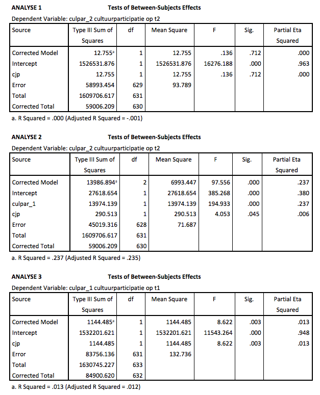

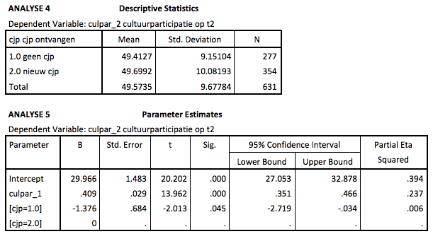

   Hoe kun je toetsen of voldaan is aan de assumptie van de ‘homogeneity of regression slopes’ van ANCOVA is voldaan?
   1. **FALSE:** Door aan analyse 2 de interactie tussen culpar_1 en cjp toe te voegen; de *F*-waarde van het ‘corrected model’ toetst deze assumptie
   2. **TRUE:** Door aan analyse 2 de interactie tussen culpar_1 en cjp toe te voegen; de *F*-waarde van het interactie-effect tussen beide toetst de assumptie
   3. **FALSE:** Door culpar_1 als afhankelijke variabele te nemen en cjp als onafhankelijke; de *F*-waarde van het ‘corrected model’ toetst deze assumptie
   4. **FALSE:** Door culpar_1 als afhankelijke variabele te nemen en cjp als onafhankelijke; de *F*-waarde van het interactie-effect tussen beide toetst de assumptie
   1. False
   2. True
   3. False
   4. False